# Análisis Exploratorio de Datos

2024-07-14

## Descripción de las variables

## Presentación del dataset

El dataset

trees

de

RStudio

contiene información sobre la circunferencia (Girth), altura (Height) y volumen (Volume) de 31 árboles.

Código:

```{r, echo=TRUE, message = FALSE, comment = NA}

`# Cargar el dataset`

`data(trees)`

`# Ver todas las filas del dataset`

`head(trees,31)`

```

## Presentación del dataset

OUTPUT:

```
##    Girth Height Volume
## 1    8.3     70   10.3
## 2    8.6     65   10.3
## 3    8.8     63   10.2
## 4   10.5     72   16.4
## 5   10.7     81   18.8
## 6   10.8     83   19.7
## 7   11.0     66   15.6
## 8   11.0     75   18.2
## 9   11.1     80   22.6
## 10  11.2     75   19.9
## 11  11.3     79   24.2
## 12  11.4     76   21.0
## 13  11.4     76   21.4
## 14  11.7     69   21.3
```

[output cut: 17 more lines]

## Análisis de las variables del dataset

## Variables

El dataset trees incluye las siguientes variables:

Girth:

- Descripción: Diámetro del tronco del árbol a 4.5 pies del suelo.
- Escala: Pulgadas.
- Tipo: Continua.

Height:

- Descripción: Altura del árbol.
- Escala: Pies.
- Tipo: Continua.

## Variables

Volume:

- Descripción: Volumen de madera del árbol.
- Escala: Pies cúbicos.
- Tipo: Continua.

Para llevar a cabo este análisis, emplearemos diversas medidas estadísticas que nos proporcionarán una visión detallada de cada variable del dataset. Estas medidas incluyen la media, mediana, moda, varianza, desviación estándar, rango, valores máximo y mínimo, coeficiente de variación, simetría y curtosis.

## Medidas

Código:

```{r, echo=FALSE, message = FALSE}

```
medidas <- function(x) {    # Mostrar resultados
c(Media = mean(x),# Media aritmetica
Mediana = median(x),# Valor central
Moda = as.numeric(names(sort(table(x), decreasing = TRUE)[1])),# Valor mas frecuente
Varianza = var(x),# Dispersion de los datos
Desviacion_Estandar = sd(x),# Raiz cuadrada de la varianza
Rango = diff(range(x)),# Diferencia entre el valor maximo y minimo
Maximo = max(x),# Valor maximo
Minimo = min(x),# Valor minimo
Coeficiente_Variacion = sd(x) / mean(x),# Relación entre la desviacion estandar y la media
Simetria = skewness(x),  # Medida de asimetria de la distribucion
Curtosis = kurtosis(x))} # Medida de la "altura" de la distribucion
# Aplicar la funcion a cada variable del dataset trees
resultados <- sapply(trees, medidas)
print(resultados)   # Mostrar resultados
```

```

## Medidas

```
##                            Girth      Height      Volume
## Media                 13.2483871 76.00000000  30.1709677
## Mediana               12.9000000 76.00000000  24.2000000
## Moda                  11.0000000 80.00000000  10.3000000
## Varianza               9.8479140 40.60000000 270.2027957
## Desviacion_Estandar    3.1381386  6.37181293  16.4378464
## Rango                 12.3000000 24.00000000  66.8000000
## Maximo                20.6000000 87.00000000  77.0000000
## Minimo                 8.3000000 63.00000000  10.2000000
## Coeficiente_Variacion  0.2368695  0.08383964   0.5448233
## Simetria               0.5010559 -0.35687727   1.0132739
## Curtosis              -0.7109412 -0.72336766   0.2460393
```

## Interpretación de las Medidas (Análisis por Variable)

## Girth

- Media: 13.2483871. Indica que el ancho promedio de los objetos medidos es aproximadamente 13.25 unidades.
- Mediana: 12.9. La mitad de los anchos son menores o iguales a 12.9, y la otra mitad son mayores o iguales a 12.9.
- Moda: 11. El valor más frecuentemente observado en el conjunto de datos es 11.
- Varianza: 9.8479140. Muestra la dispersión de los anchos alrededor de la media. Cuanto mayor sea el valor, mayor será la variabilidad.
- Desviación Estándar: 3.1381386. Indica la cantidad promedio que los anchos difieren de la media. Es la raíz cuadrada de la varianza.
- Rango: 12.3. La diferencia entre el valor máximo y mínimo observado en los anchos.
- Máximo: 20.6. El ancho más grande registrado.
- Mínimo: 8.3. El ancho más pequeño registrado.

## Girth

- Coeficiente de Variación: 0.2368695. Expresa la desviación estándar como proporción de la media. Un valor bajo indica menos variabilidad.
- Simetría (Asimetría): 0.5010559. Indica la asimetría de la distribución. Valores positivos indican una distribución sesgada hacia la derecha, y negativos hacia la izquierda.
- Curtosis: -0.7109412. Mide la “altura” de la distribución. Valores negativos indican una cola pesada a la izquierda, lo que significa que los valores extremos son más probables de lo esperado en una distribución normal.

## Height

- Media: 76. La altura promedio de los objetos es 76 unidades.
- Mediana: 76. La mitad de las alturas son menores o iguales a 76, y la otra mitad son mayores o iguales a 76.
- Moda: 80. El valor más frecuentemente observado en las alturas es 80.
- Varianza: 40.6. Indica la dispersión de las alturas alrededor de la media.
- Desviación Estándar: 6.37. Muestra la cantidad promedio que las alturas difieren de la media.
- Rango: 24. La diferencia entre el valor máximo y mínimo observado en las alturas.

## Height

- Máximo: 87. La altura más alta registrada.
- Mínimo: 63. La altura más baja registrada.
- Coeficiente de Variación: 0.08383964. Indica la variabilidad relativa de las alturas.
- Simetría (Asimetría): -0.357. Sugiere una leve asimetría hacia la izquierda.
- Curtosis: -0.723. Indica una cola pesada a la izquierda, similar a la observada en la Girth.

## Volume

- Media: 30.171. El volumen promedio de los objetos es aproximadamente 30.17 unidades cúbicas.
- Mediana: 24.2. La mitad de los volúmenes son menores o iguales a 24.2, y la otra mitad son mayores o iguales a 24.2.
- Moda: 10.3. El valor más frecuentemente observado en los volúmenes es 10.3.
- Varianza: 270.2. Muestra la dispersión de los volúmenes alrededor de la media.
- Desviación Estándar: 16.44. Indica la cantidad promedio que los volúmenes difieren de la media.
- Rango: 66.8. La diferencia entre el valor máximo y mínimo observado en los volúmenes.

## Volume

- Máximo: 77. El volumen más grande registrado.
- Mínimo: 10.2. El volumen más pequeño registrado.
- Coeficiente de Variación: 0.5448233. Indica la variabilidad relativa de los volúmenes.
- Simetría (Asimetría): 1.013. Sugiere una distribución sesgada hacia la derecha.
- Curtosis: 0.246. Indica una distribución con colas más pesadas que una distribución normal, lo que sugiere una menor probabilidad de ocurrencia de valores extremos.

## Visualización de los Datos

## Histograma de distribución del volumen

```{r, echo=FALSE, message = FALSE}

```
library(ggplot2)
# Definir la funcion para formatear las etiquetas como enteros
format_enteros <- function(x) {
    round(x)
}
# Crear el histograma
ggplot(trees, aes(x = Volume)) +
    geom_histogram(binwidth = 5, fill = "skyblue", color = "black") +
    scale_y_continuous(labels = function(x) format_enteros(x)) +
    # Aplicar la funcion para formatear las etiquetas
    theme_classic() +
    labs(title = "Distribución del Volumen de los Árboles",
        x = "Volume (pies cúbicos)",
        y = "Frecuencia")
```

```

## Histograma de distribución del volumen

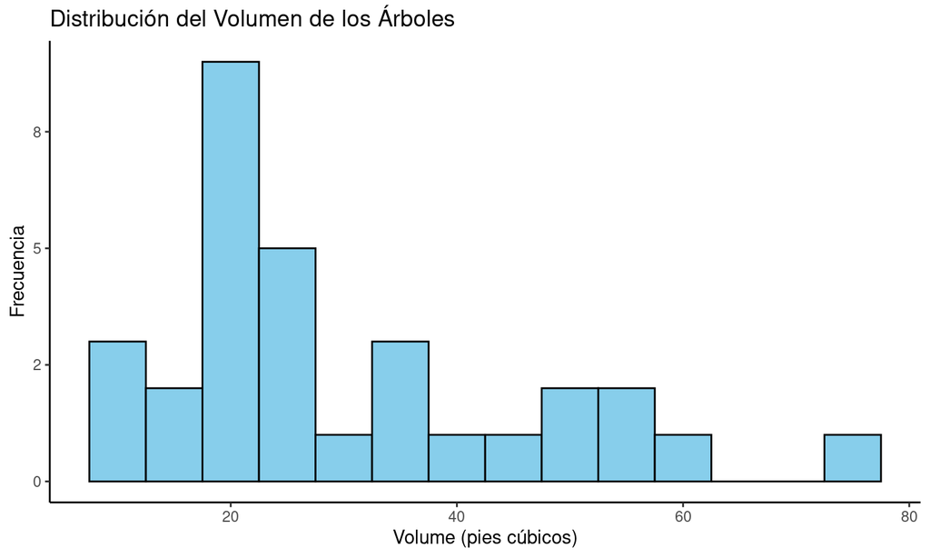

## Interpretación

- Variabilidad: La variabilidad en los volúmenes de los árboles se puede observar en la dispersión de las barras a lo largo del eje X. Aunque la mayoría de los árboles tienen volúmenes entre 0 y 40 pies cúbicos, hay algunos que alcanzan hasta 80 pies cúbicos.

## Boxplot de la altura de los árboles

```{r, echo=FALSE, message = FALSE}

```
# Grafica de Boxplot
ggplot(trees, aes(x = "", y = Height)) +
    geom_boxplot(fill = "lightgreen", color = "darkgreen") +
    theme_light() +
    labs(title = "Boxplot de la Altura de los Árboles",
        x = "",
        y = "Height (altura en pies)")
```

```

## Boxplot de la altura de los árboles

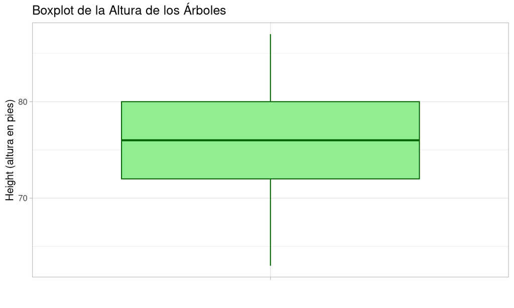

## Gráfico de Barras de Girth

```{r, echo=FALSE, message = FALSE}

```
# Grafico de barras para Girth
barplot(table(cut(trees$Girth, breaks = 5)),
        main = "Grafico de barras de Girth",
        xlab = "Intervalos de Girth",
        ylab = "Frecuencia",
        col = "lightblue",
        border = "black")
```

```

## Gráfico de Barras de Girth

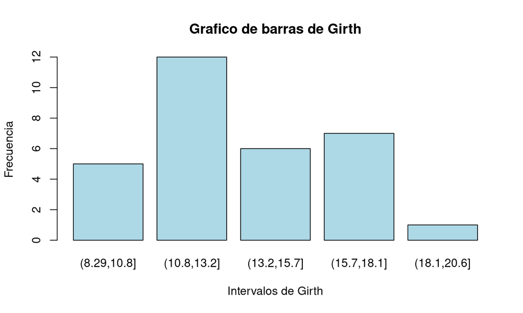

## Interpretación

- Intervalos de Girth: El gráfico de barras muestra la frecuencia de los diámetros de los árboles (Girth) en diferentes intervalos. Esto nos permite ver cómo se distribuyen los diámetros en el dataset.
- Frecuencia: La altura de cada barra representa el número de árboles que caen dentro de cada intervalo de diámetro. Por ejemplo, si una barra es más alta, significa que hay más árboles con diámetros en ese rango específico.
- Tendencias: Observando el gráfico, podemos identificar si hay algún intervalo de diámetro que sea más común. Esto puede ser útil para entender las características predominantes de los árboles en el dataset.

## Relación entre las variables

## Scatterplot de Relación entre Girth y Height

```{r, echo=FALSE, message = FALSE}

```
# Grafica de Scatter plot
ggplot(trees, aes(x = Girth, y = Height)) +
    geom_point(color = "darkorange", size = 3) +
    theme_minimal() +
    labs(title = "Relación entre Girth y Height",
        x = "Girth (circunferencia en pulgadas)",
        y = "Height (altura en pies)")
```

```

## Scatterplot de Relación entre Girth y Height

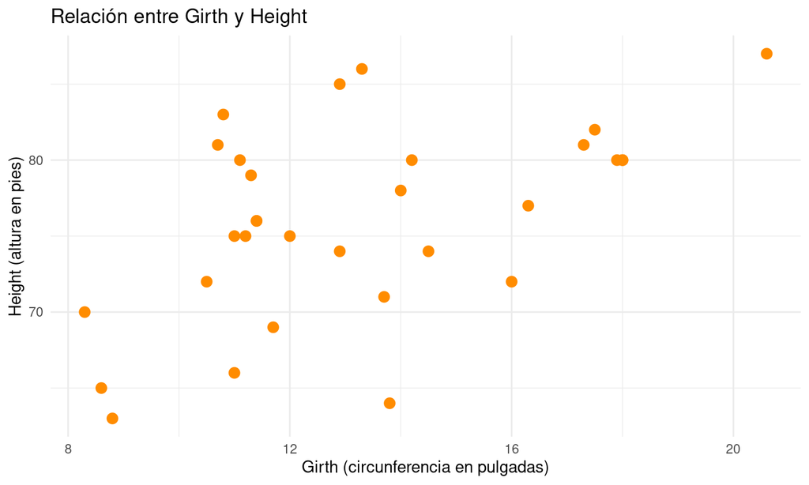

## Interpretación

La tendencia positiva sugiere que, en general, los árboles con mayor circunferencia tienden a ser más altos. Sin embargo, la dispersión de los puntos también indica que hay variabilidad y posibles valores atípicos que merecen una investigación más detallada.

## Matriz de Correlación

```{r, echo=FALSE, message = FALSE}

```
# Matriz de correlación
cor(trees)

# Cargar librerias necesarias
library(ggplot2)
library(reshape2)

# Calcular la matriz de correlación
cor_matrix <- cor(trees)
```

```

## Matriz de Correlación

```
##            Girth    Height    Volume
## Girth  1.0000000 0.5192801 0.9671194
## Height 0.5192801 1.0000000 0.5982497
## Volume 0.9671194 0.5982497 1.0000000
```

## Gráfica de Mosaico

```{r, echo=FALSE, message = FALSE}

```
# Convertir la matriz de correlación en un formato largo
cor_data <- melt(cor_matrix)
# Crear la gráfica de la matriz de correlación
ggplot(data = cor_data, aes(x = Var1, y = Var2, fill = value)) +
    geom_tile() +
    scale_fill_gradient2(low = "blue", high = "red", mid = "white",
                        midpoint = 0, limit = c(-1, 1), space = "Lab",
                        name="Correlación") +
    theme_minimal() +
    theme(axis.text.x = element_text(angle = 45, vjust = 1,
                                    size = 12, hjust = 1)) +
    coord_fixed() +
    labs(title = "Matriz de Correlación del Dataset Trees",
        x = "Variables",
        y = "Variables")
```

```

## Gráfica de Mosaico

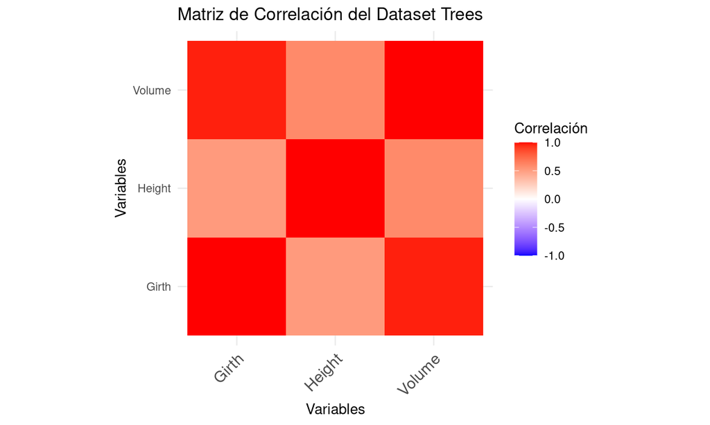

## Descripción

- melt() de reshape2 convierte la matriz de correlación en un formato de datos largo (long format). Esto es necesario porque ggplot2 trabaja mejor con datos en formato largo o ancho (wide format) para ciertos tipos de gráficos.
- geom_tile(): Crea un gráfico de mosaico (tile plot) donde cada celda representa la correlación entre dos variables.
- scale_fill_gradient2(): Define cómo se deben colorear las celdas basándose en su valor de correlación. En este caso, los valores negativos se muestran en azul, los positivos en rojo, y los cercanos a cero en blanco.
- theme_minimal(): Aplica un tema minimalista al gráfico.
- coord_fixed(): Asegura que las unidades de medida sean consistentes en ambos ejes.
- labs(): Define títulos y etiquetas para los ejes y el gráfico completo.

## Descripción

- Diagonal Principal (Girth, Height, Volume):Estos valores son todos 1, lo que significa que cada característica tiene una correlación perfecta consigo misma. Es decir, un árbol grande (alto giro) será siempre grande (alto volumen) y viceversa, ya que estamos hablando de la misma característica medida en diferentes formas.

## Relación entre pares de Variables

## Girth vs Height

- Girth vs Height: 0.5192801: Esta correlación indica que hay una relación positiva moderada entre el giro y la altura de los árboles. Esto significa que los árboles más grandes tienden a ser también más altos, pero no hay una correlación perfecta, lo que sugiere que hay otros factores involucrados además del tamaño del tronco.

## Fin

[figure not shown]